# Different charting libraries

2016-03-23

This is intended as a gallery / cookbook of different visualisation libraries in R. You can toggle overall code visibility in the top right-hand corner.

If you can improve the code or expand the charts or packages included, then please do so! [Go to repo](https://github.com/stephlocke/chartgallery)

# General packages

## Notes

The ggvis gallery is currently seperate as it has an old version of the vega library resulting in problems with the vegalite package right now.

## ggplot2

ggplot2 is the way most people make plots with R these days.

```r
source("genericprep.R")
if(!require(ggplot2)) install.packages("ggplot2")
library(ggplot2)

# Network chart
if(!require(GGally)) install.packages("GGally")
if(!require(network)) install.packages("network")
library(GGally)

# Beeswarm
if(!require(ggbeeswarm)) install.packages("ggbeeswarm")
library(ggbeeswarm)
```

### Basic

#### Bar chart

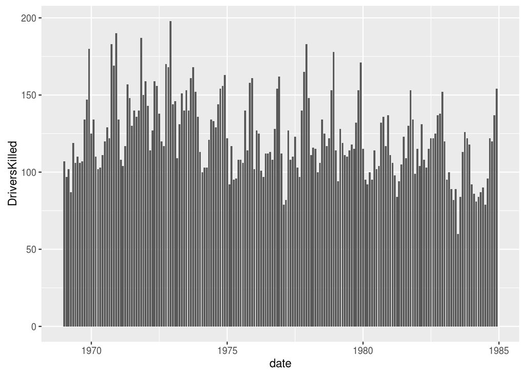

```r
ggplot(seatbelts, aes(x=date, y=DriversKilled)) +
  geom_bar(stat="identity")
```

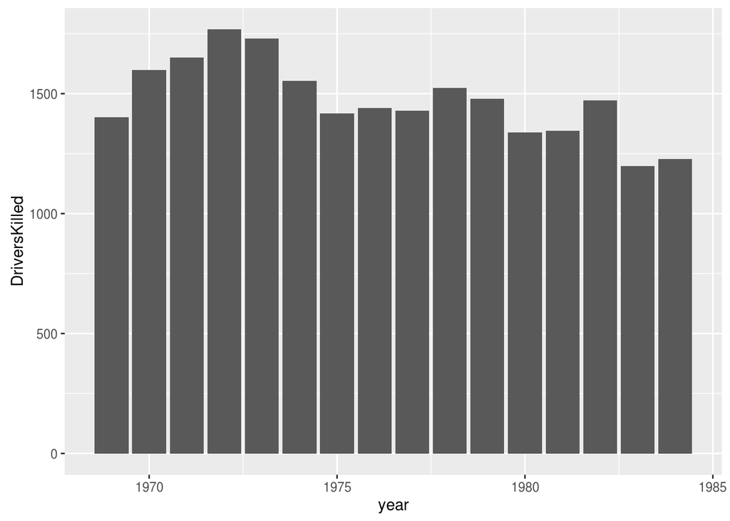

```r
seatbeltsAgg<-seatbelts[
  ,.(DriversKilled = sum(DriversKilled))
  ,year]

ggplot(seatbeltsAgg, aes(x=year, y=DriversKilled)) +
  geom_bar(stat="identity")
```

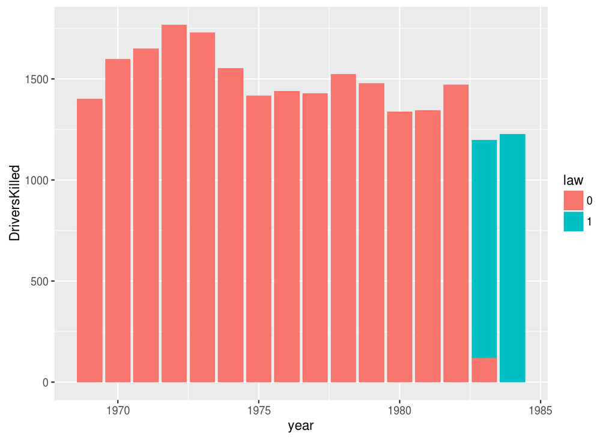

```r
seatbeltsAgg<-seatbelts[
  ,.(DriversKilled = sum(DriversKilled))
  ,.(year,law=as.factor(law))]

ggplot(seatbeltsAgg, aes(x=year, y=DriversKilled
                         , group=law, fill=law)) +
  geom_bar(stat="identity")
```

#### Scatter plot

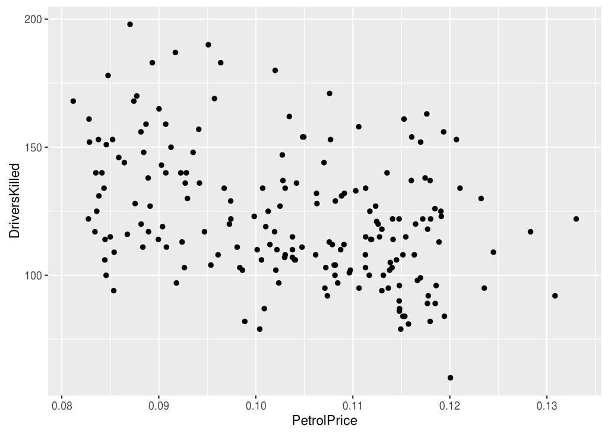

```r
ggplot(seatbelts, aes(x=PetrolPrice, y=DriversKilled)) +
  geom_point()
```

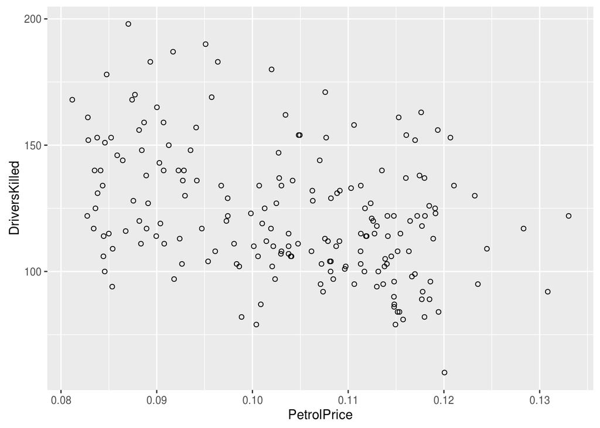

```r
ggplot(seatbelts, aes(x=PetrolPrice, y=DriversKilled)) +
  geom_point(shape=1)
```

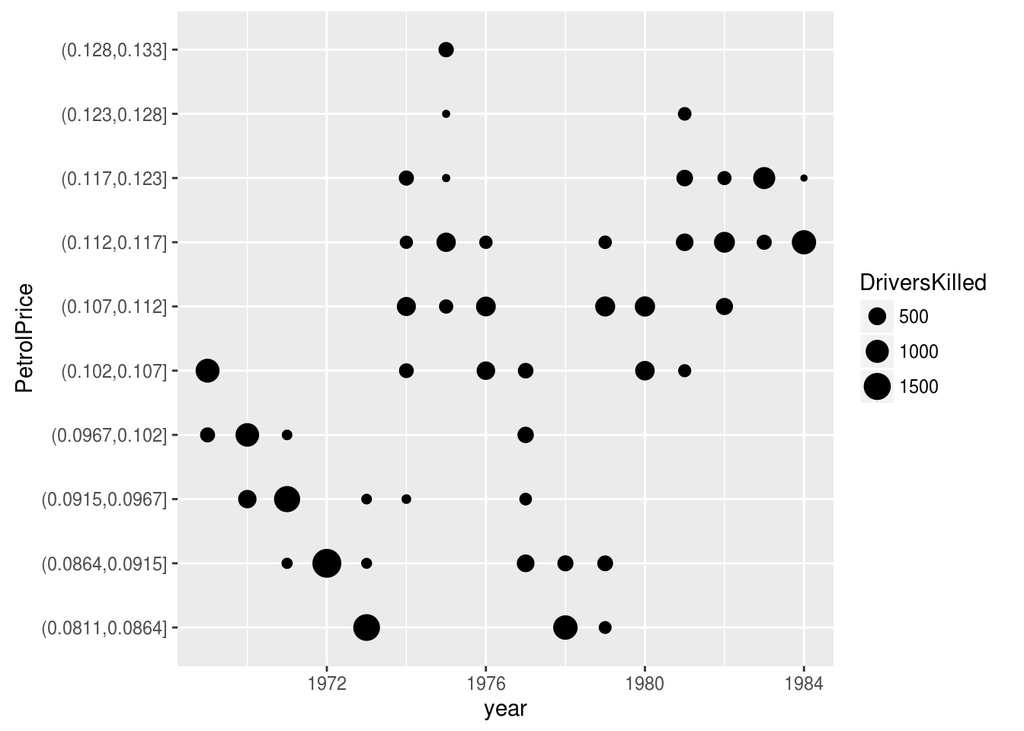

```r
seatbeltsAgg<-seatbelts[
  ,.(DriversKilled = sum(DriversKilled))
  ,.(year,PetrolPrice=cut(PetrolPrice,breaks = 10))]

ggplot(seatbeltsAgg, aes(x=year, y=PetrolPrice
                         , size=DriversKilled)) +
  geom_point()
```

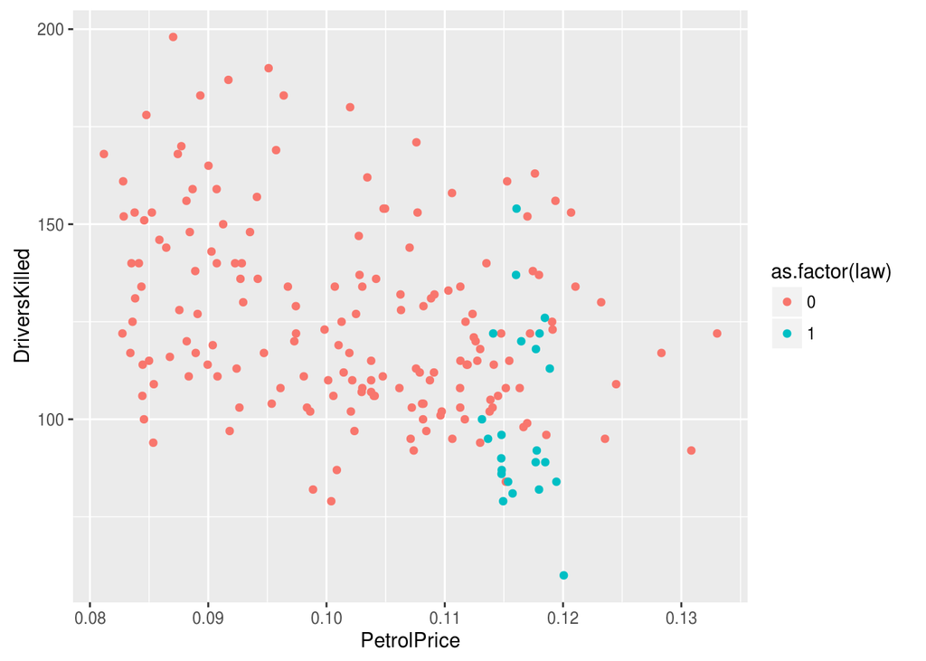

```r
ggplot(seatbelts, aes(x=PetrolPrice, y=DriversKilled
                      , colour = as.factor(law))) +
  geom_point()
```

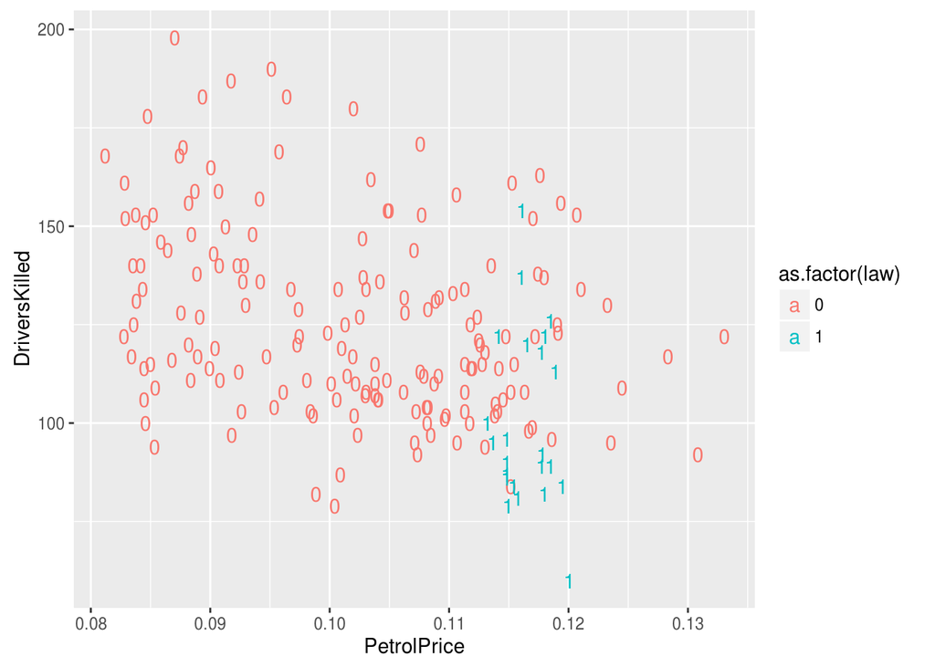

```r
ggplot(seatbelts, aes(x=PetrolPrice, y=DriversKilled
                      , colour = as.factor(law)
                      , label = as.factor(law))) +
  geom_text()
```

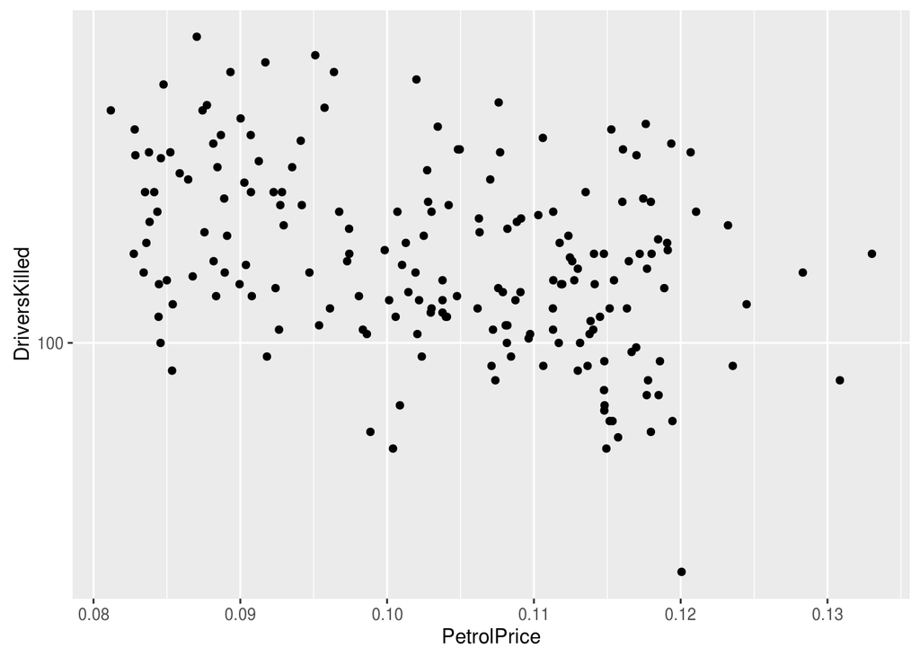

```r
ggplot(seatbelts, aes(x=PetrolPrice, y=DriversKilled)) +
  geom_point() +
  scale_y_log10()
```

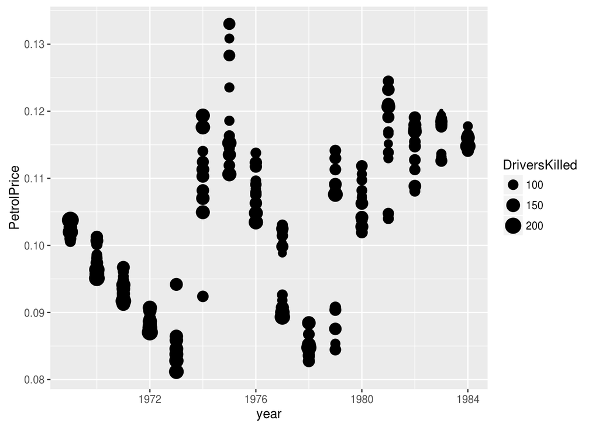

```r
seatbeltsAgg<-seatbelts[
  ,.(DriversKilled = sum(DriversKilled))
  ,.(year,PetrolPrice)]

ggplot(seatbeltsAgg, aes(x=year, y=PetrolPrice
                         , size=DriversKilled)) +
  geom_point()
```

#### Line chart

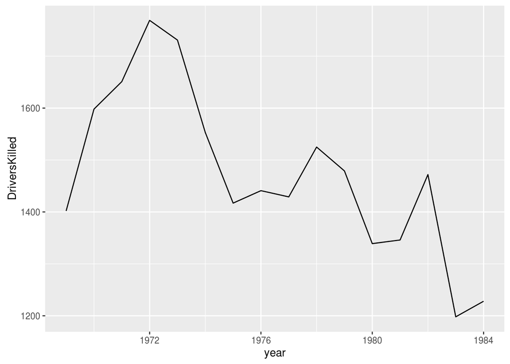

```r
seatbeltsAgg<-seatbelts[
  ,.(DriversKilled = sum(DriversKilled))
  ,year]

ggplot(seatbeltsAgg, aes(x=year, y=DriversKilled)) +
  geom_line()
```

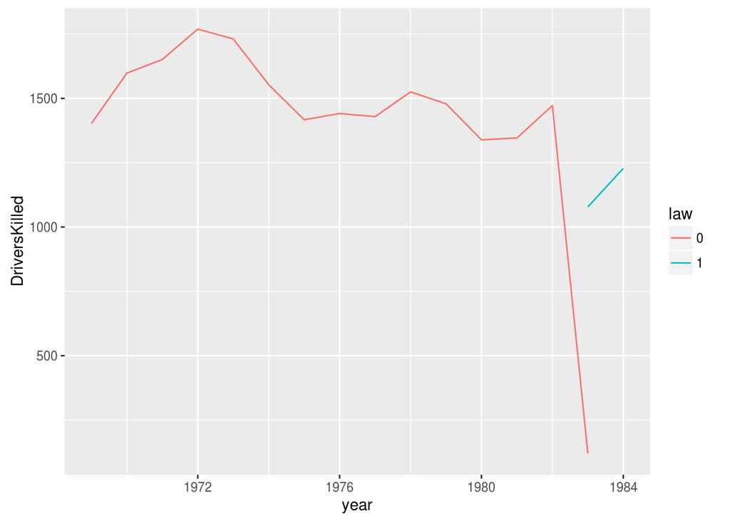

```r
seatbeltsAgg<-seatbelts[
  ,.(DriversKilled = sum(DriversKilled))
  ,.(year, law=as.factor(law))]

ggplot(seatbeltsAgg, aes(x=year, y=DriversKilled
                         , group=law , colour=law)) +
  geom_line()
```

#### Others

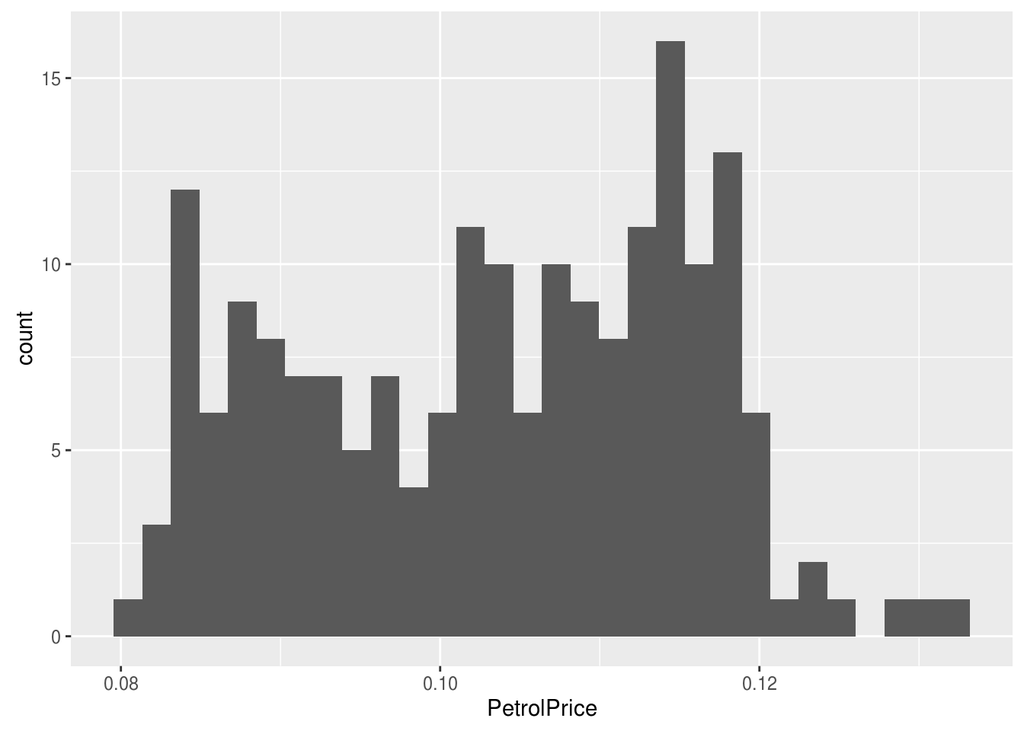

```r
ggplot(seatbelts, aes(x=PetrolPrice, y=..count..) )+
  geom_histogram()
```

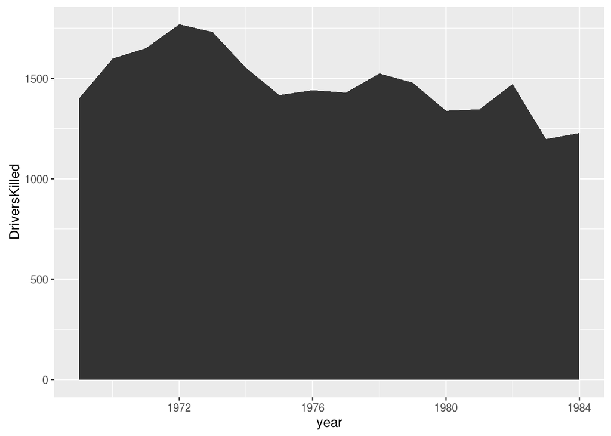

```r
seatbeltsAgg<-seatbelts[
  ,.(DriversKilled = sum(DriversKilled))
  ,year]

ggplot(seatbeltsAgg, aes(x=year, y=DriversKilled)) +
  geom_area()
```

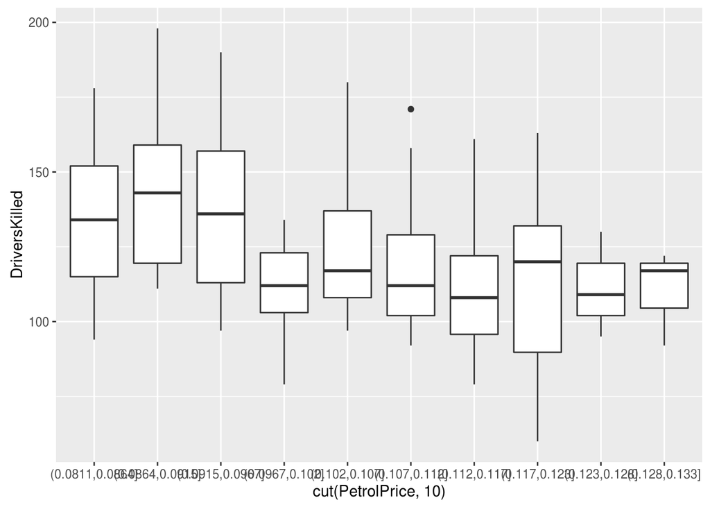

```r
ggplot(seatbelts, aes(x=cut(PetrolPrice,10), y=DriversKilled)) +
  geom_boxplot()
```

### Stacked and Layered Plots

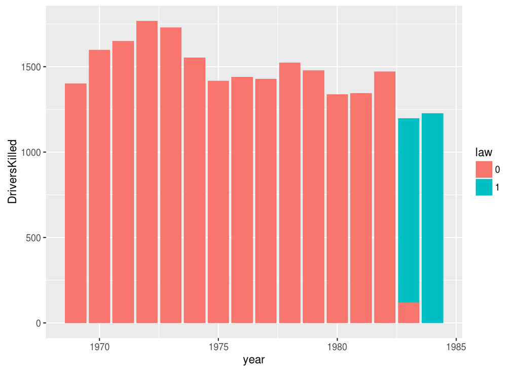

```r
seatbeltsAgg<-seatbelts[
  ,.(DriversKilled = sum(DriversKilled))
  ,.(year,law=as.factor(law))]

ggplot(seatbeltsAgg, aes(x=year, y=DriversKilled
                         ,fill=law)) +
  geom_bar(stat="identity")
```

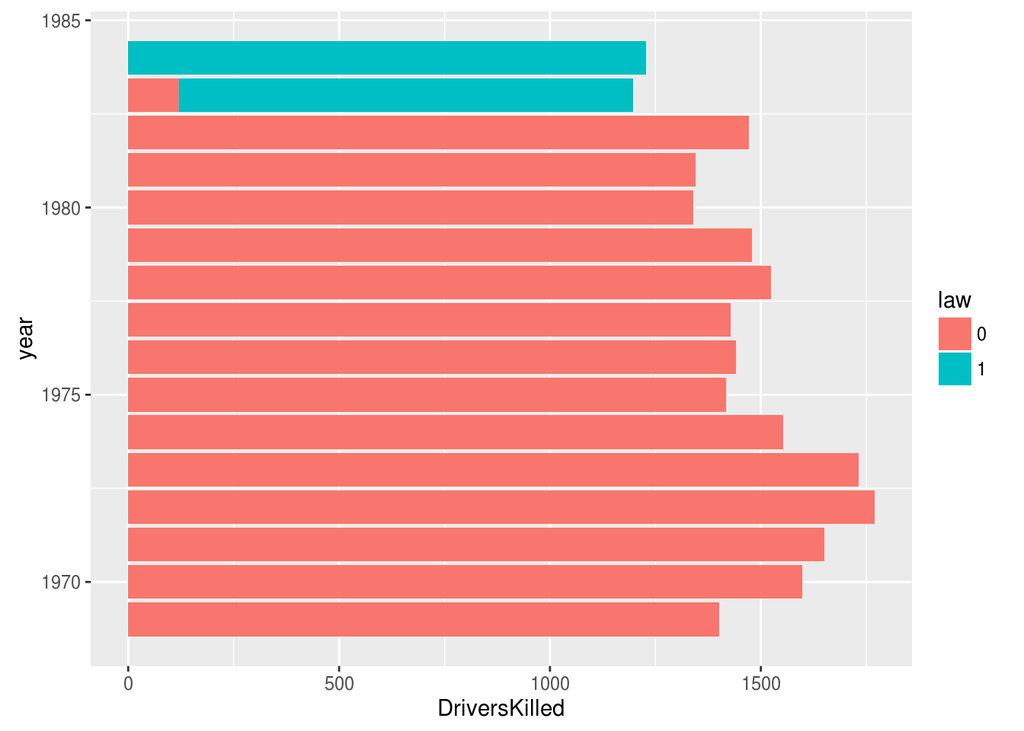

```r
seatbeltsAgg<-seatbelts[
  ,.(DriversKilled = sum(DriversKilled))
  ,.(year,law=as.factor(law))]

ggplot(seatbeltsAgg, aes(x=year, y=DriversKilled
                         ,fill=law)) +
  geom_bar(stat="identity") +
  coord_flip()
```

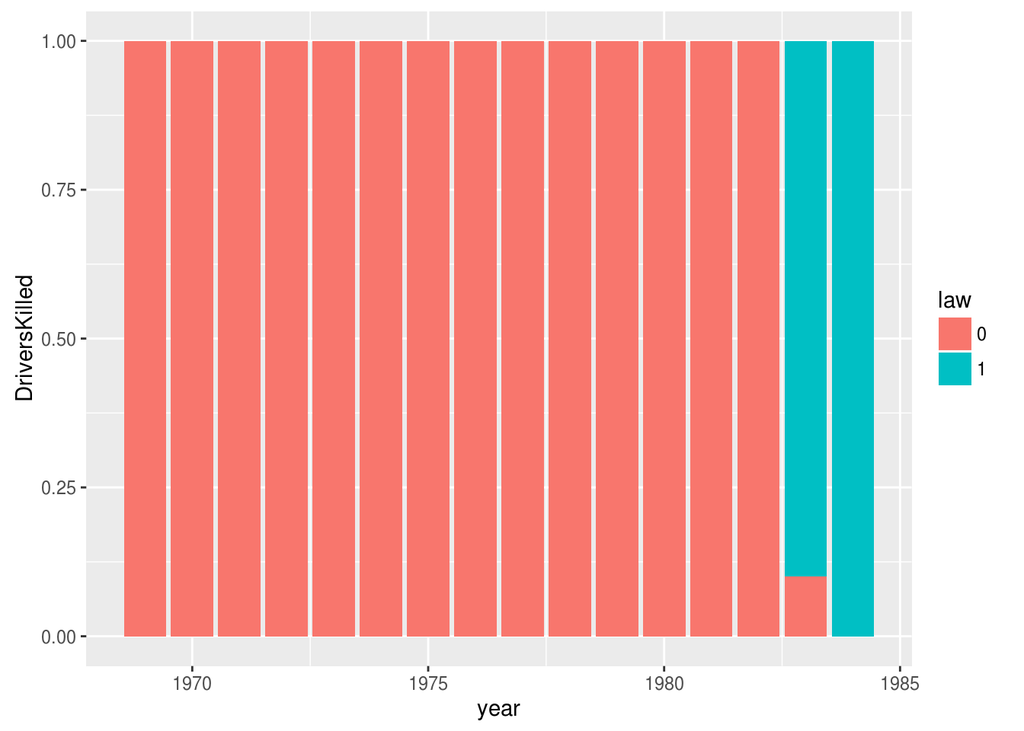

```r
seatbeltsAgg<-seatbelts[
  ,.(DriversKilled = sum(DriversKilled))
  ,.(year,law=as.factor(law))]

ggplot(seatbeltsAgg, aes(x=year, y=DriversKilled
                         ,fill=law)) +
  geom_bar(stat="identity",position = "fill")
```

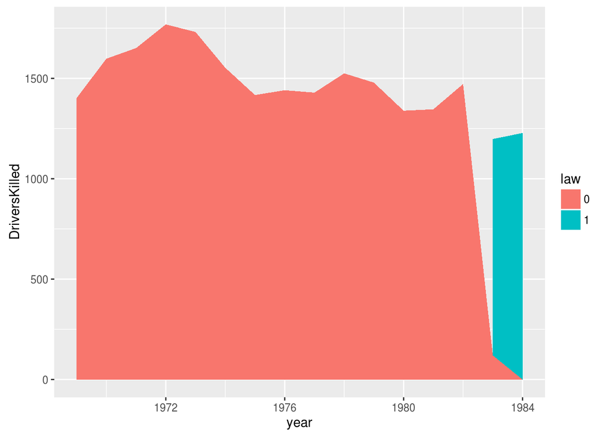

```r
seatbeltsAgg<-seatbelts[
  ,.(DriversKilled = sum(DriversKilled))
  ,.(year,law=as.factor(law))]
dummyRow<-data.table(year=1984,law=0,DriversKilled=0)
seatbeltsAgg <- rbindlist(list(seatbeltsAgg,dummyRow), use.names=TRUE,fill=TRUE)

ggplot(seatbeltsAgg[order(year,law),], aes(x=year, y=DriversKilled
                         ,fill=law)) +
  geom_area(position="stack")
```

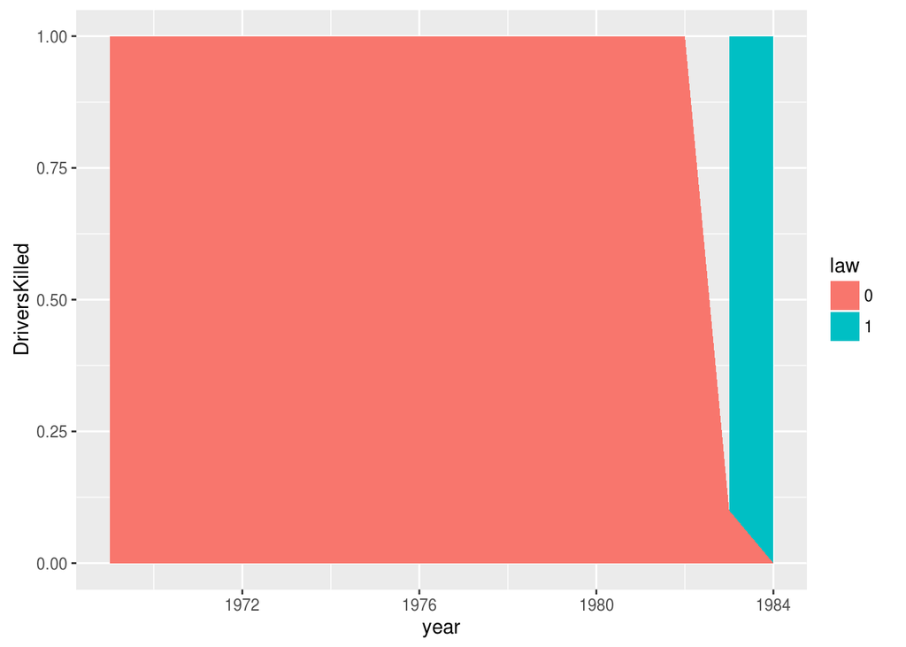

```r
seatbeltsAgg<-seatbelts[
  ,.(DriversKilled = sum(DriversKilled))
  ,.(year,law=as.factor(law))]
dummyRow<-data.table(year=1984,law=0,DriversKilled=0)
seatbeltsAgg <- rbindlist(list(seatbeltsAgg,dummyRow), use.names=TRUE,fill=TRUE)

ggplot(seatbeltsAgg[order(year,law),], aes(x=year, y=DriversKilled
                                           ,fill=law)) +
  geom_area(position="fill")
```

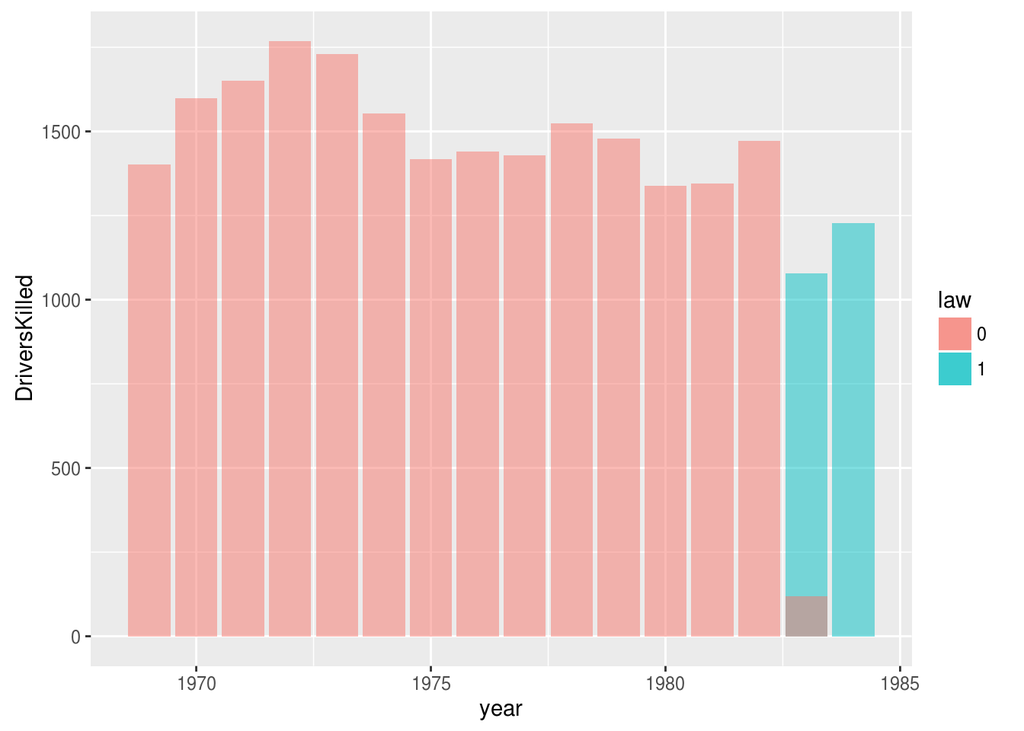

```r
# This is inelegant!
seatbeltsAgg<-seatbelts[
  ,.(DriversKilled = sum(DriversKilled))
  ,.(year,law=as.factor(law))]

ggplot( mapping = aes(x=year, y=DriversKilled
                         ,fill=law)) +
  geom_bar(data=seatbeltsAgg[law=="1",],stat="identity", alpha=.5)+
  geom_bar(data=seatbeltsAgg[law=="0",],stat="identity", alpha=.5)
```

### Trellis Plots

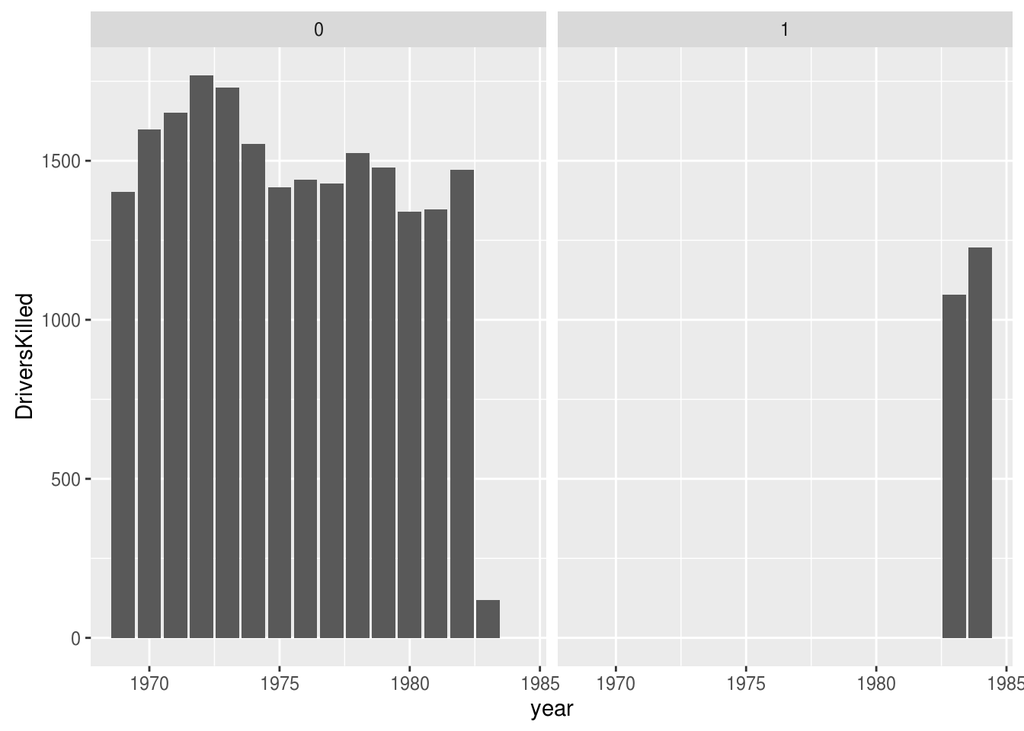

```r
seatbeltsAgg<-seatbelts[
  ,.(DriversKilled = sum(DriversKilled))
  ,.(year,law)]

ggplot(seatbeltsAgg, aes(x=year, y=DriversKilled)) +
  geom_bar(stat="identity")+
  facet_wrap(~law)
```

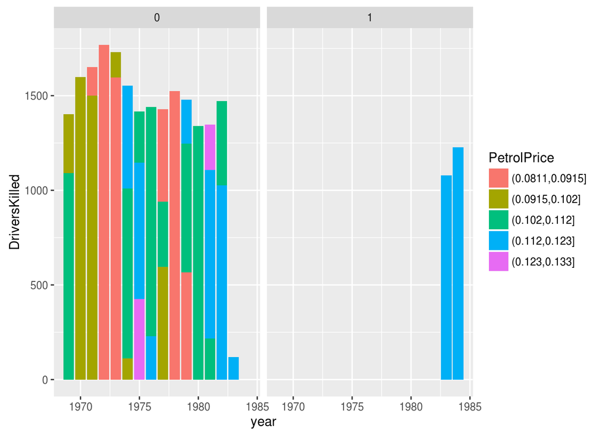

```r
seatbeltsAgg<-seatbelts[
  ,.(DriversKilled = sum(DriversKilled))
  ,.(year,law,PetrolPrice=cut(PetrolPrice,breaks = 5))]

ggplot(seatbeltsAgg, aes(x=year, y=DriversKilled, fill=PetrolPrice)) +
  geom_bar(stat="identity")+
  facet_wrap(~law)
```

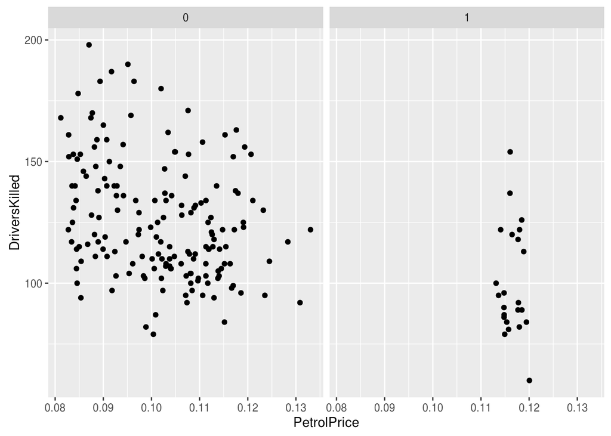

```r
ggplot(seatbelts, aes(x=PetrolPrice, y=DriversKilled)) +
  geom_point()+
  facet_wrap(~law)
```

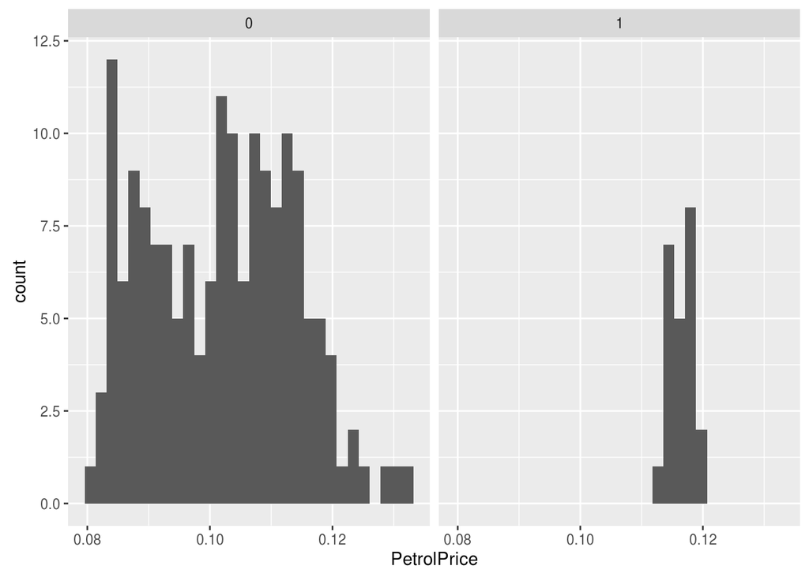

```r
ggplot(seatbelts, aes(x=PetrolPrice, y=..count..) )+
  geom_histogram()+
  facet_wrap(~law)
```

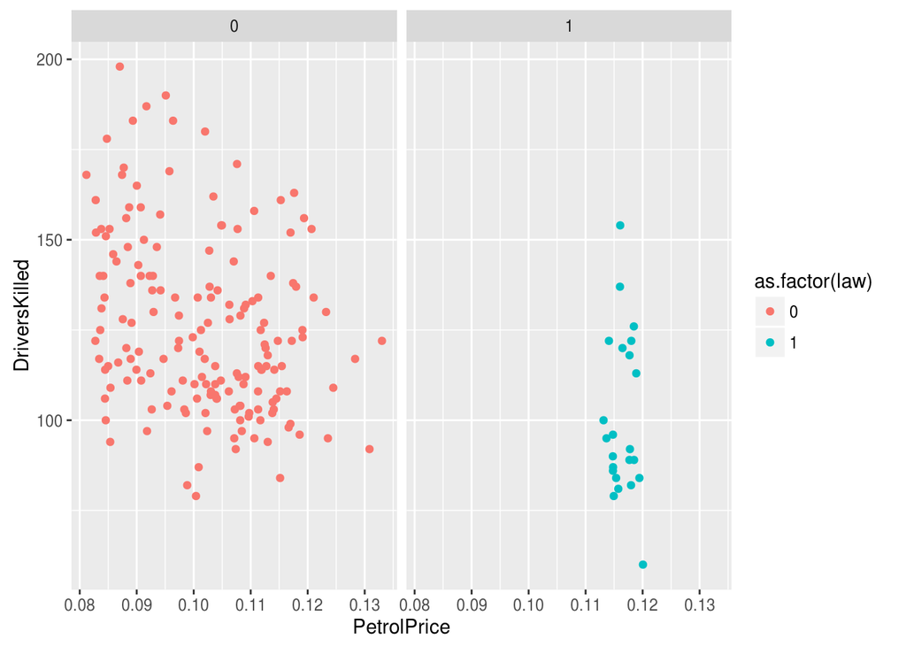

```r
ggplot(seatbelts, aes(x=PetrolPrice, y=DriversKilled
                      , colour = as.factor(law))) +
  geom_point()+
  facet_wrap(~law)
```

### Uncommon charts

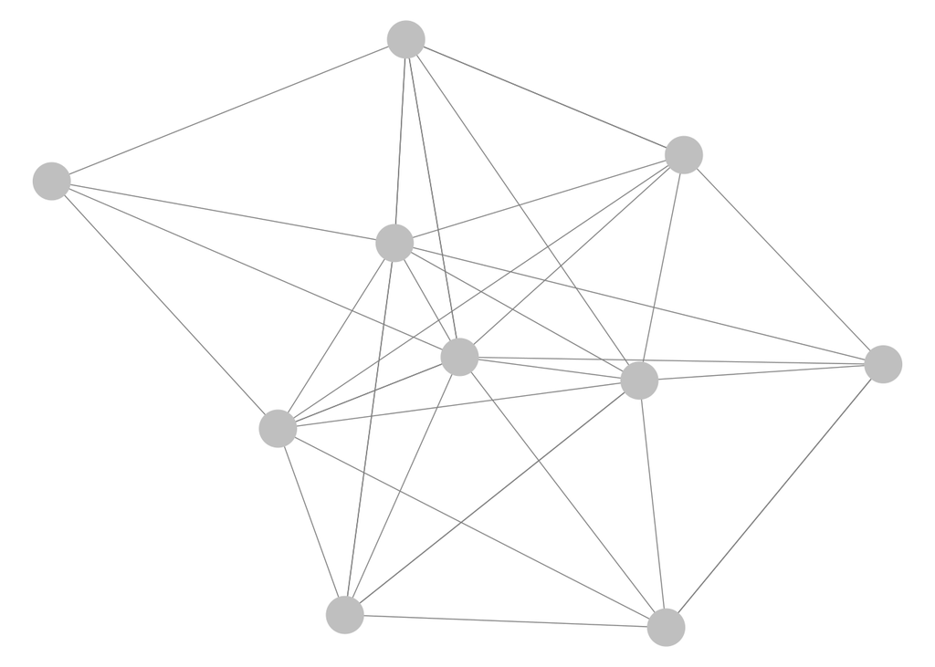

```r
GGally::ggnet2(graphNet)
```

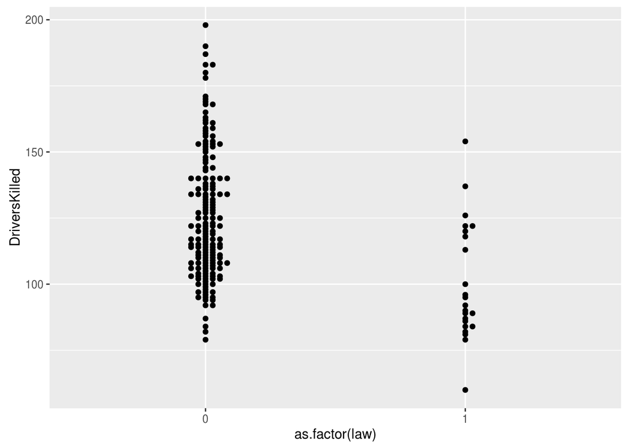

```r
ggplot(seatbelts, aes(x=as.factor(law), y=DriversKilled)) +
  ggbeeswarm::geom_beeswarm()
```

## vegalite

[Vega](http://vega.github.io/vega/) is a grammar of graphics implementation that takes JSON and converts the results to HTML5 or SVG. [Vega-Lite](https://vega.github.io/vega-lite/) provides layer over the top of Vega to reduce the burden of generating the JSON specifications required.

[Bob Rudis](http://rud.is/) developed an R binding of vegalite, currently available on github( hrbrmstr/vegalite ).

Much of the code used in this is taken from, or loosely based on, the code Bob wrote in [his reproduction](http://rud.is/projects/vegalite01.html) of the Vega gallery.

```r
source("genericprep.R")
# Not on CRAN
if(!require(devtools)) install.packages("devtools")
if(!require(vegalite)) {
  devtools::install_github("hrbrmstr/vegalite")
}
library(vegalite)
vegalite <- vegalite(viewport_height = "300px")
```

### Basic

#### Bar chart

```r
vegalite %>%
  add_data(seatbelts) %>%
  encode_x("date","ordinal") %>%
  encode_y("DriversKilled", "quantitative") %>%
  mark_bar()
```

[interactive chart not shown]

```r
vegalite %>%
  add_data(seatbelts) %>%
  encode_x("year","ordinal") %>%
  encode_y("DriversKilled", "quantitative","sum") %>%
  mark_bar()
```

[interactive chart not shown]

```r
vegalite %>%
  add_data(seatbelts) %>%
  encode_x("year","ordinal") %>%
  encode_y("DriversKilled", "quantitative","sum") %>%
  encode_color("law", "nominal") %>%
  mark_bar()
```

[interactive chart not shown]

#### Scatter plot

```r
vegalite %>%
  add_data(seatbelts) %>%
  encode_x("PetrolPrice","quantitative") %>%
  encode_y("DriversKilled", "quantitative") %>%
  mark_point()
```

[interactive chart not shown]

```r
vegalite %>%
  add_data(seatbelts) %>%
  encode_x("PetrolPrice","quantitative") %>%
  encode_y("DriversKilled", "quantitative") %>%
  mark_circle()
```

[interactive chart not shown]

```r
vegalite %>%
  add_data(seatbelts) %>%
  encode_x("year","ordinal") %>%
  encode_y("PetrolPrice", "quantitative") %>%
  encode_size("DriversKilled", "quantitative", aggregate="sum") %>%
  bin_y(maxbins=10) %>%
  mark_point()
```

[interactive chart not shown]

```r
vegalite %>%
  add_data(seatbelts) %>%
  encode_x("PetrolPrice","quantitative") %>%
  encode_y("DriversKilled", "quantitative") %>%
  encode_color("law", "nominal") %>%
  mark_point()
```

[interactive chart not shown]

```r
vegalite %>%
  add_data(seatbelts) %>%
  encode_x("PetrolPrice","quantitative") %>%
  encode_y("DriversKilled", "quantitative") %>%
  encode_color("law", "nominal") %>%
  encode_text("law", "nominal") %>%
  mark_text()
```

[interactive chart not shown]

```r
vegalite %>%
  add_data(seatbelts) %>%
  encode_x("year","ordinal") %>%
  encode_y("DriversKilled", "quantitative")  %>%
  scale_y_log() %>%
  mark_point()
```

[interactive chart not shown]

```r
vegalite %>%
  add_data(seatbelts) %>%
  encode_x("year","ordinal") %>%
  encode_y("PetrolPrice", "quantitative") %>%
  encode_size("DriversKilled", "quantitative", aggregate="sum") %>%
  mark_point()
```

[interactive chart not shown]

#### Line chart

```r
vegalite %>%
  add_data(seatbelts) %>%
  encode_x("year","ordinal") %>%
  encode_y("DriversKilled", "quantitative", "sum")  %>%
  mark_line()
```

[interactive chart not shown]

```r
vegalite %>%
  add_data(seatbelts) %>%
  encode_x("year","ordinal") %>%
  encode_y("DriversKilled", "quantitative", "sum")  %>%
  encode_color("law", "nominal") %>%
  mark_line()
```

[interactive chart not shown]

#### Others

```r
vegalite %>%
  add_data(seatbelts) %>%
  encode_x("PetrolPrice","quantitative") %>%
  encode_y("DriversKilled", "quantitative", "sum") %>%
  bin_x(maxbins=10) %>%
  mark_bar()
```

[interactive chart not shown]

```r
vegalite %>%
  add_data(seatbelts) %>%
  encode_x("year","ordinal") %>%
  encode_y("DriversKilled", "quantitative", "sum")  %>%
  mark_area()
```

[interactive chart not shown]

### Stacked and Layered Plots